# IODS course project

Santeri Rouhinen

# Regression and model validation

*Describe the work you have done this week and summarize your learning.*

This week I did the regression homework. Having done the DataCamp exercises there was very little new to do in the RStudio exercise itself. Seems a bit pointless to do the RStudio exercise as you could pretty much copy-paste the code from the DataCamp and be done. To make things a bit more complicated for myself I added some complexity not requested in the exercise.

Data wrangling I had done before, so that was not new, but a good reminder. I had done regression with R before, but the validation/prediction stuff was new. I also found that rather than directly coding in .Rmd one should code in .R. Seems easier at least.

- Describe your work and results clearly.
- Assume the reader has an introductory course level understanding of writing and reading R code as well as statistical methods
- Assume the reader has no previous knowledge of your data or the more advanced methods you are using

## Analysis part

1. Read data to local folder
2. Show a graphical overview
3. Choose explanatory variables
4. Explain the relationship between the variables.
5. Check for model validity. (This should be 4?)

### 1.

In this part data is loaded into a data frame. Information about the dataset can be found in [here](http://www.helsinki.fi/~kvehkala/JYTmooc/JYTOPKYS3-meta.txt). In brief it has data on students, their attitudes, learning styles, basic demographics and exam scores.

```r
# Read data from a local comma separated values file.
learning2014 <- read.csv("data/learning2014.csv")

# Get dimensions of the data (166 students and 8 observations). Get structure.
dim(learning2014)
```

```
## [1] 166   8
```

```r
str(learning2014)
```

```
## 'data.frame':    166 obs. of  8 variables:
##  $ X       : int  1 2 3 4 5 6 7 8 9 10 ...
##  $ gender  : Factor w/ 2 levels "F","M": 1 2 1 2 2 1 2 1 2 1 ...
##  $ age     : int  53 55 49 53 49 38 50 37 37 42 ...
##  $ attitude: num  3.7 3.1 2.5 3.5 3.7 3.8 3.5 2.9 3.8 2.1 ...
##  $ deep    : num  3.58 2.92 3.5 3.5 3.67 ...
##  $ stra    : num  3.38 2.75 3.62 3.12 3.62 ...
##  $ surf    : num  2.58 3.17 2.25 2.25 2.83 ...
##  $ points  : int  25 12 24 10 22 21 21 31 24 26 ...
```

```r
# The dataset has been collapsed from a dataset measured by Kimmo Vehkalahti.
# Deep, stra and surf refer to deep, strategic and surface learning values normalized to 1-5.
```

### 2.

Do some graphs and tables.

```r
# Show a graphical overview of the data and show summaries of the variables in the data. X is the numeric order of the students.
library(ggplot2)
library(GGally)
```

```r
# Text table of the dataset
summary(learning2014)
```

```
##        X          gender       age           attitude          deep
##  Min.   :  1.00   F:110   Min.   :17.00   Min.   :1.400   Min.   :1.583
##  1st Qu.: 42.25   M: 56   1st Qu.:21.00   1st Qu.:2.600   1st Qu.:3.333
##  Median : 83.50           Median :22.00   Median :3.200   Median :3.667
##  Mean   : 83.50           Mean   :25.51   Mean   :3.143   Mean   :3.680
##  3rd Qu.:124.75           3rd Qu.:27.00   3rd Qu.:3.700   3rd Qu.:4.083
##  Max.   :166.00           Max.   :55.00   Max.   :5.000   Max.   :4.917
##       stra            surf           points
##  Min.   :1.250   Min.   :1.583   Min.   : 7.00
##  1st Qu.:2.625   1st Qu.:2.417   1st Qu.:19.00
##  Median :3.188   Median :2.833   Median :23.00
##  Mean   :3.121   Mean   :2.787   Mean   :22.72
##  3rd Qu.:3.625   3rd Qu.:3.167   3rd Qu.:27.75
##  Max.   :5.000   Max.   :4.333   Max.   :33.00
```

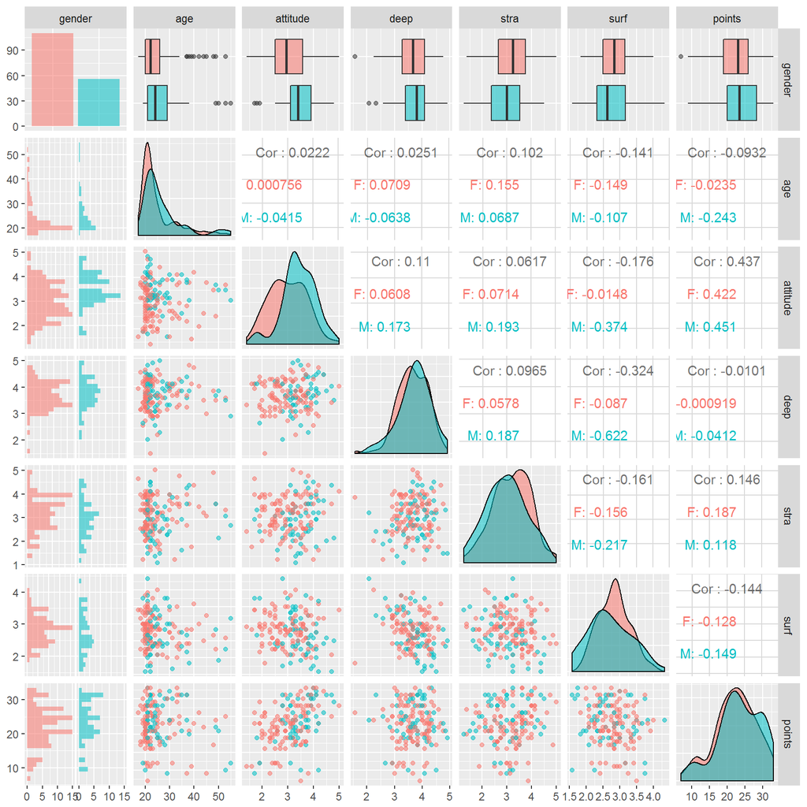

```r
# initialize plot with data and aesthetic mapping
p1 <- ggplot(learning2014, aes(x = attitude, y = points))

# define the visualization type (points)
p2 <- p1 + geom_point()

# add a regression line
p3 <- p2 + geom_smooth(method = "lm")

# add a main title and draw the plot
p4 <- p3 + ggtitle("Student's attitude versus exam points")

# add equation and r-squared to the graph after linear model has been done.


# create a more advanced plot matrix with ggpairs()
pp <- ggpairs(learning2014[-1], mapping = aes(col = gender, alpha = 0.3), lower = list(combo = wrap("facethist", bins = 20)))

# draw the plot
pp
```

```r
shapiro.test(learning2014$deep)
```

```
##
##  Shapiro-Wilk normality test
##
## data:  learning2014$deep
## W = 0.9812, p-value = 0.02371
```

```r
shapiro.test(learning2014$stra)
```

```
##
##  Shapiro-Wilk normality test
##
## data:  learning2014$stra
## W = 0.99068, p-value = 0.3504
```

```r
shapiro.test(learning2014$surf)
```

```
##
##  Shapiro-Wilk normality test
##
## data:  learning2014$surf
## W = 0.99219, p-value = 0.5073
```

```r
shapiro.test(learning2014$points)
```

```
##
##  Shapiro-Wilk normality test
##
## data:  learning2014$points
## W = 0.96898, p-value = 0.0008932
```

### 3.

Explore how well different student attributes predict their exam points.

```r
## Perform an explanatory model with a regression model. Choose three variables. Drop non-significant ones and redo.
# Do a linear model.
lModel <- lm(points ~ attitude + stra + surf, data = learning2014)
summary(lModel)
```

```
##
## Call:
## lm(formula = points ~ attitude + stra + surf, data = learning2014)
##
## Residuals:
##      Min       1Q   Median       3Q      Max
## -17.1550  -3.4346   0.5156   3.6401  10.8952
##
## Coefficients:
##             Estimate Std. Error t value Pr(>|t|)
## (Intercept)  11.0171     3.6837   2.991  0.00322 **
## attitude      3.3952     0.5741   5.913 1.93e-08 ***
## stra          0.8531     0.5416   1.575  0.11716
## surf         -0.5861     0.8014  -0.731  0.46563
## ---
## Signif. codes:  0 '***' 0.001 '**' 0.01 '*' 0.05 '.' 0.1 ' ' 1
##
## Residual standard error: 5.296 on 162 degrees of freedom
## Multiple R-squared:  0.2074, Adjusted R-squared:  0.1927
## F-statistic: 14.13 on 3 and 162 DF,  p-value: 3.156e-08
```

```r
# Surface learning is not even close to significant. The strategic learning is marginally significant. So drop surf.
lModel <- lm(points ~ attitude + stra, data = learning2014)
summary(lModel)
```

```
##
## Call:
## lm(formula = points ~ attitude + stra, data = learning2014)
##
## Residuals:
##      Min       1Q   Median       3Q      Max
## -17.6436  -3.3113   0.5575   3.7928  10.9295
##
## Coefficients:
##             Estimate Std. Error t value Pr(>|t|)
## (Intercept)   8.9729     2.3959   3.745  0.00025 ***
## attitude      3.4658     0.5652   6.132 6.31e-09 ***
## stra          0.9137     0.5345   1.709  0.08927 .
## ---
## Signif. codes:  0 '***' 0.001 '**' 0.01 '*' 0.05 '.' 0.1 ' ' 1
##
## Residual standard error: 5.289 on 163 degrees of freedom
## Multiple R-squared:  0.2048, Adjusted R-squared:  0.1951
## F-statistic: 20.99 on 2 and 163 DF,  p-value: 7.734e-09
```

```r
# After dropping surf strategic learning is also p>0.05 so drop that also. Only attitude remains.
lModel <- lm(points ~ attitude, data = learning2014)
summary(lModel)
```

```
##
## Call:
## lm(formula = points ~ attitude, data = learning2014)
##
## Residuals:
##      Min       1Q   Median       3Q      Max
## -16.9763  -3.2119   0.4339   4.1534  10.6645
##
## Coefficients:
##             Estimate Std. Error t value Pr(>|t|)
## (Intercept)  11.6372     1.8303   6.358 1.95e-09 ***
## attitude      3.5255     0.5674   6.214 4.12e-09 ***
## ---
## Signif. codes:  0 '***' 0.001 '**' 0.01 '*' 0.05 '.' 0.1 ' ' 1
##
## Residual standard error: 5.32 on 164 degrees of freedom
## Multiple R-squared:  0.1906, Adjusted R-squared:  0.1856
## F-statistic: 38.61 on 1 and 164 DF,  p-value: 4.119e-09
```

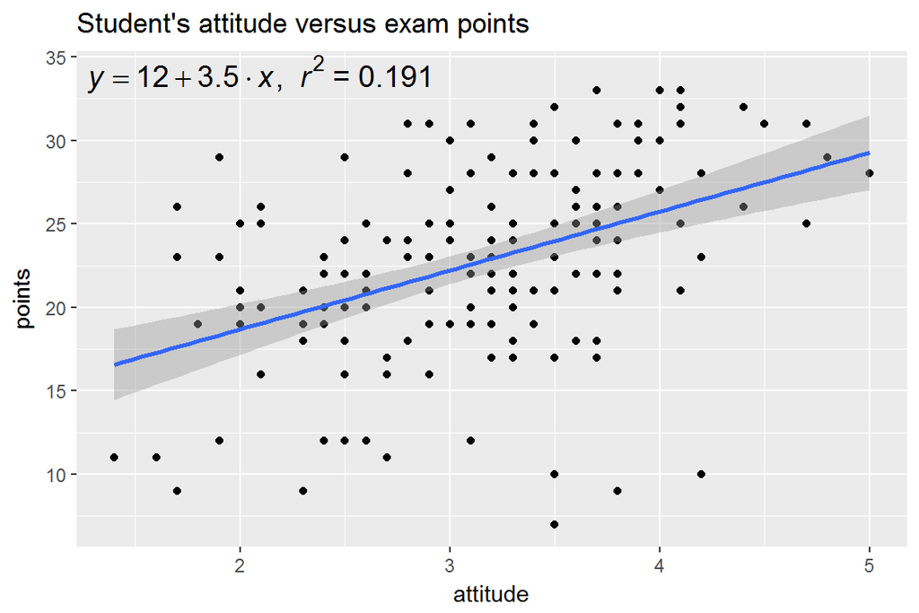

```r
# Add regression formula to the attitude vs points plot.
# Function to get regression formula.
lm_eqn = function(m) {

  l <- list(a = format(coef(m)[1], digits = 2),
            b = format(abs(coef(m)[2]), digits = 2),
            r2 = format(summary(m)$r.squared, digits = 3));

  if (coef(m)[2] >= 0)  {
    eq <- substitute(italic(y) == a + b %.% italic(x)*","~~italic(r)^2~"="~r2,l)
  } else {
    eq <- substitute(italic(y) == a - b %.% italic(x)*","~~italic(r)^2~"="~r2,l)
  }

  as.character(as.expression(eq));
}

p5 = p4 + annotate("text", x = 2.1, y = 34, label = lm_eqn(lModel), colour="black", size = 5, parse=TRUE)
p5
```

Linear regression can be described with a formula dependent = alpha + beta(explanatoryVariable) + noise One can have more than one explanatory variables. In this case only attitude remains as a statistically significant explanatory variable. In the current model alpha is 11.6 and beta is 3.5. That is each attitude attribute point is worth 3.5 points in the exam.

### 4.

**Interpretation**.

Multiple R-squared value is 0.19. Multiple R-squared is known as R-squared. It tells how well the model fits the data. A value of 1 means the model perfectly predicts data, whereas 0 means there is no predictive value. The value of 19 % means that roughly 19 percent of the course score in the learning2014 dataset is explained by the attitude rating. It can help to think that R-squared is correlation coefficient x correlation coefficient. If one was using multiple variables using the Adjusted R-squared value would be recommended.

### 5.

Validation of model sanity.

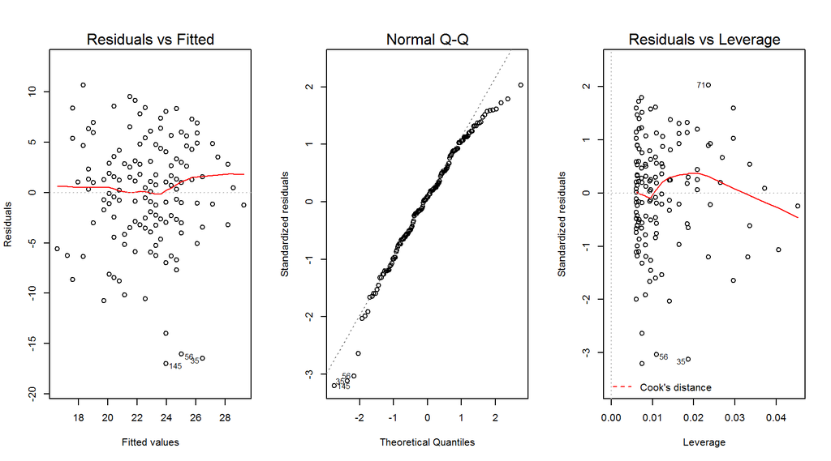

```r
## Check if model fits well or not.
# draw diagnostic plots using the plot() function. Choose the plots 1, 2 and 5.
# Draw three panels in a single figure.
par(mfrow = c(1,3))
# Plot Residuals vs Fitted values (1), Normal QQ-plot (2), and Residuals vs Leverage (5).
plot(lModel, which = c(1,2,5))
```

Linear regression model assumes linearly distributed data and normally distributed errors. Errors should also have constant variance. One can display graphs to test how well the model fits the assumption.

Residuals vs Fitted plot is used to check if variance is constant or not. If the data points are roughly evenly distributed good, if the data has a clear shape then bad. Residuals vs Fitted is roughly evenly distributed, so the size of errors should not depend on the explanatory variables.

Q-Q plot is used to measure whether errors are normally distributed. If points follow the line then normality can be presumed. Q-Q plot seems reasonably near the assumption of normal error distribution.

All in all the model seems reasonable.